# Uträkning av hartreepotential

[figure not shown]

För att beräkna Hartreepotentialen $V_\text{H}$ undersöks först Hartree-energin $E_\text{H}[n]$, som uppkommer av Coloumbkrafterna mellan elektronerna i atomen. Bidraget approximeras genom att summera energin som krävs för att föra två klassiska punktladdningar nära varandra:

\begin{equation*} dE_\text{H} = \frac{1}{4\pi \epsilon_0}\frac{q'\cdot q}{|\vec{r}' - \vec{r}|}=\frac{e^2}{4\pi \epsilon_0}\frac{n(\vec{r}')dV' \cdot n(\vec{r})dV}{|\vec{r}' - \vec{r}|} \Rightarrow E_\text{H}[n] = \frac{1}{2} \iint \frac{n(\vec{r}')n(\vec{r})}{|\vec{r}' - \vec{r}|} dV' dV \end{equation*}

Efter summering av den totala energin har en faktor $\frac{1}{2}$ introducerats. Detta beror på att när energin summeras beräknas bidragen dubbelt, när $\vec{r}$ och $\vec{r}'$ byter plats.

där $dV$ är ett litet volymelement och $e^2/4\pi\epsilon_0 = 1$ i atomära enheter. Hartreepotentialen blir

\begin{equation} \label{V_H} V_\text{H}(\vec{r}) = 2 \cdot \frac{\delta E_\text{H}[n]}{\delta n} = \int \frac{n(\vec{r})}{|\vec{r}' - \vec{r}|} dV \end{equation}

I denna uträkning har laddningarna i rummet approximerats till klassiska partiklar och kvantmekaniska bidrag tas därför inte i hänsyn -- dessa är inkluderade i exchange-korrelationpotentialen $V_\text{xc}$.

# Implementation

Uttrycket \eqref{V_H} är lösningen till Poissons ekvation, det vill säga

$$\begin{equation} \label{poisson} \nabla^2V_\text{H}(\vec{r}) = -4\pi n(\vec{r}). \end{equation}$$

Detta görs för hela systemet. För att göra detta lite enklare undersöks spinnen var för sig genom att introducera nya funktioner

$$ 2 V_\text{sH}(\vec{r}) = V_\text{H}(\vec{r}) $$

och

$$ 2 n_\text{s}(\vec{r}) = n(\vec{r}) $$

där s betecknar "spinn", alltså tätheten och hartree potential för elektroner med samma spinn.

I polära koordinater är detta problemet krångligt, men ett variabel kan göras, delvis för att erhålla lätthanterliga randvillkor samt för att göra problemet lämpligt i polära koordinater. Vidare är problemet rotationssymmetriskt, villket innebär att $n_\text{s}(\vec{r}) = n_\text{s}(r)$ och $V_\text{sH}(\vec{r}) = V_\text{sH}(r)$.

Med följande koordinatbyten

$$ U(r) = rV_\text{sH}(r) - \frac{r}{r_\text{max}} $$

och

$$\begin{equation} \label{u_replace} \sqrt{4 \pi n_\text{s}(r)} r = u(r) % \Rightarrow \int n_\text{s}(\vec{r}) dV = \iiint n_\text{s}(r) r^2 \sin(\theta) dr d\theta d\varphi = \int u(r) dr \end{equation}$$

blir Poissons ekvation \eqref{poisson} på formen

$$\begin{equation} \label{problem} \frac{d^2}{dr^2}U(r) = -\frac{u^2(r)}{r} \end{equation}$$

Variabelbytena innebär att $u(0) = 0$ och att $n(r_\text{max}) = 0 \Rightarrow \lim_{r\rightarrow\infty}u(r) = 0$, eftersom $n(r)$ är normerbar. Vidare är $U(0) = 0$ och $U(r_\text{max}) = 0$ \cite{comphys}.

$$\begin{equation*} \frac{d^2}{dr^2} = \frac{1}{h^2} \begin{bmatrix} 2 & -1 & 0 & 0 & \dots & 0 \\ -1 & 2 & -1 & 0 & \dots & 0 \\ 0 & -1 & 2 & -1 & \dots & 0 \\ \vdots & \vdots & \ddots & \ddots & \ddots & \vdots \\ 0 & \dots & 0 & -1 & 2 & -1 \\ 0 & \dots & 0 & 0 & -1 & 2 \end{bmatrix} \end{equation*}$$

detta görs med funktionen `get_gradient_matrix` som ligger i `components.gradient`. Implentationen blir

```python
from components.gradient import get_gradient_matrix
import numpy as np

def get_VH(r, n):
    # Matrix for second derivative
    ddr2 = get_gradient_matrix(r)

    # Get u from density n
    u = np.sqrt(4 * np.pi * n)*r

    # Solve the poisson problem
    U = np.linalg.solve(ddr2, -u[1:-1]**2/r[1:-1])

    ## Add boundary points
    U = np.concatenate(([0], U, [0]))

    ## Calculate one electron hartree potential
    U = U + r / r[-1]

    # Avoid dividing by zero (r[0] = 0)
    V_sH = U[1:] / r[1:]

    # Interpolate to get the first point of Hartree potential
    V_sH = np.concatenate(([1], V_sH))
    return 2 * V_sH
```

Vi undersöker hur Hartreepotentialen ser ut med $n$ med intiala gissningen.

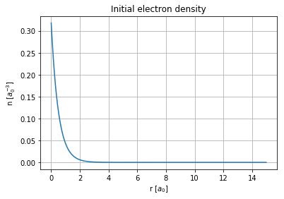

```python
%matplotlib inline
import matplotlib.pyplot as plt
import scipy.integrate

r_max = 15
r_step = 0.015
r = np.arange(0, r_max, r_step)

# Initial gissning av densitet
phi = 1 / np.sqrt(np.pi) * np.exp(-r)
n = phi**2

# Plot av densiteten
plt.plot(r,n)
plt.xlabel("r [$a_0$]")
plt.ylabel("n [$a_0^{-3}$]")
plt.title("Initial electron density")
plt.grid()
plt.show()
```

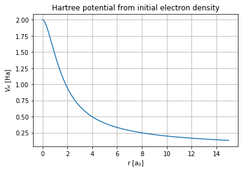

```python
# Plot av Hartreepotentialen
plt.plot(r,get_VH(r,n))
plt.xlabel("r [$a_0$]")
plt.ylabel("$V_H$ [Ha]")
plt.title("Hartree potential from initial electron density")
plt.grid()
plt.show()
```

Tillbaka till förstasidan